# IODS course project

Roope O. Kaaronen

## **Roope’s Project**

**Hello world!** Welcome to my Open Data course page. I like turtles.

*My repository link:*

https://github.com/roopekaaronen/IODS-project

## Chapter 2, Data Analysis

This week I did some data wrangling on the JYTOPKYS2 dataset (and created my own learning2014.csv file) and subsequently ran some descriptive analyses as well as multiple and simple regression analyses on the data. You’ll find the code for the wrangling in the rmd file. The conclusion of these analyses was that, according to this dataset, study attitudes affect the statistics course scores (points) significantly (p < 0.001).

*Step 1:*

I inspected the structure and dimensions of the learning2014 dataset I created in the data wrangling process.

The data had 166 observations and 7 variables. The variables are: gender (of student), age (of student), attitude (general attitude towards statistics), deep (deep learning strategies), stra (strategic learning strategies), surf (surface learning strategies) and points (score of statistics course).

*Step 2:*

Next I drew made some descriptive tables and a scatterplot matrix to explore a (graphical) overview of the data:

```
## 'data.frame':    166 obs. of  7 variables:
##  $ gender  : Factor w/ 2 levels "F","M": 1 2 1 2 2 1 2 1 2 1 ...
##  $ age     : int  53 55 49 53 49 38 50 37 37 42 ...
##  $ attitude: num  3.7 3.1 2.5 3.5 3.7 3.8 3.5 2.9 3.8 2.1 ...
##  $ deep    : num  3.58 2.92 3.5 3.5 3.67 ...
##  $ stra    : num  3.38 2.75 3.62 3.12 3.62 ...
##  $ surf    : num  2.58 3.17 2.25 2.25 2.83 ...
##  $ points  : int  25 12 24 10 22 21 21 31 24 26 ...
```

```
## [1] 166   7
```

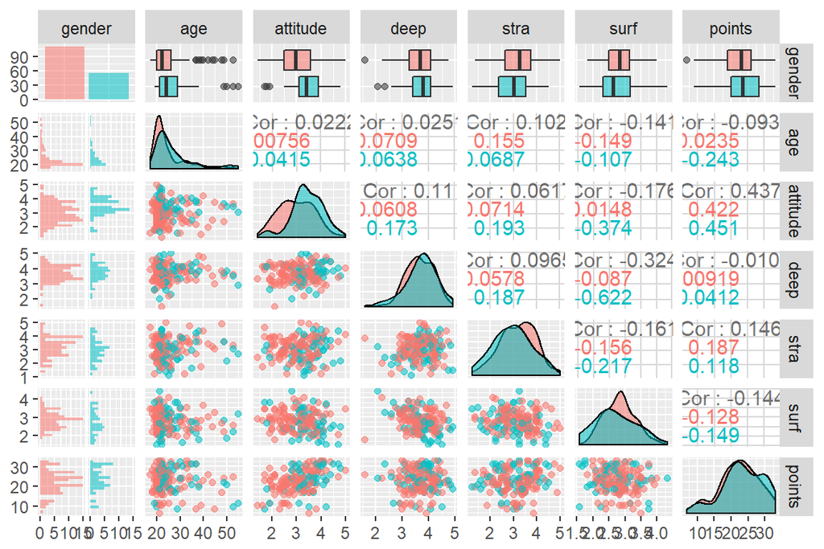

Here are some observations: Age: Age is (as expected) heavily positively skewed (since the participants are students). Mean age is 25.5. Age does not correlate strongly with any of the other variables.  
Attitude: Attitude seems to be quite normally distributed, with slight negative skew. Attitude correlates moderately with points (r = 0.437). This is an interesting finding.  
Deep: Deep learning is quite neatly normally distributed. Deep learning has weak negative correlation (r = -0.324) with surface learning. This makes sense: when deep learning increases in a student, we can expect surface learning to decrease.  
Stra: Strategic learning has a nice normal distribution, but correlations with the other variables are at best very weak.  
Surf: Surface learning correlates very weakly with the other variables (nothing significant here) except for deep learning (See above).  
Points: (When greater than zero) points averaged (mean) at 22.7, with the lowest score being 7 and the highest 33. The points distribution is negatively skewed. The distribution peaks around it’s mean, but also has a smaller peak around very high scores (around 30 points). Points have a moderate correlation with the attitude varialbe (r = 0.437).

*Step 3:*

Then I did a multiple regression model; lets see how attitude, stra and surf affect points.

```
##
## Call:
## lm(formula = points ~ attitude + stra + surf, data = learning2014)
##
## Coefficients:
## (Intercept)     attitude         stra         surf
##     11.0171       3.3952       0.8531      -0.5861
```

```
##
## Call:
## lm(formula = points ~ attitude + stra + surf, data = learning2014)
##
## Residuals:
##      Min       1Q   Median       3Q      Max
## -17.1550  -3.4346   0.5156   3.6401  10.8952
##
## Coefficients:
##             Estimate Std. Error t value Pr(>|t|)
## (Intercept)  11.0171     3.6837   2.991  0.00322 **
## attitude      3.3952     0.5741   5.913 1.93e-08 ***
## stra          0.8531     0.5416   1.575  0.11716
## surf         -0.5861     0.8014  -0.731  0.46563
## ---
## Signif. codes:  0 '***' 0.001 '**' 0.01 '*' 0.05 '.' 0.1 ' ' 1
##
## Residual standard error: 5.296 on 162 degrees of freedom
## Multiple R-squared:  0.2074, Adjusted R-squared:  0.1927
## F-statistic: 14.13 on 3 and 162 DF,  p-value: 3.156e-08
```